# R Growth Curve Analysis & Eyetracking Workshop: Tutorial 4: Growth Curve Analyses

Brock Ferguson

July 1, 2015

Load required packages.

```r
library(ggplot2)
library(lme4)
library(dplyr)
```

Load our eyetracking data.

```r
data <- read.csv('data-eyetracking.csv')
```

Note: In this tutorial, we will do by-subjects time analyses only (aggregating across trials within-subjects) for simplicity but you can do by-items/trials analyses in the same way if you aggregate within trials instead of subjects.

# Bin data within participants by time

Let’s prep these data for analysis much like we prepped for the empirical logit analysis.

```r
# rescale, bin, aggregate, and transform our DV's all in one step
binned <- data %>%
        mutate(TimeS = TimeFromSubphaseOnset / 1000,
               Bin = TimeFromSubphaseOnset %/% 50) %>% # re-scale, bin
        group_by(ParticipantName,Target,Bin) %>% # aggregate within bins
        summarise(PropAnimal = mean(Animate), y = sum(Animate), N = length(Animate), TimeS = min(TimeS)) %>%
        mutate(elog = log( (y + .5) / (N - y + .5) ), # empirical logit
               wts = 1/(y + .5) + 1/(N - y + .5), # optional weights
               Arcsin = asin(sqrt(PropAnimal))) %>% # arcsin-sqrt
        ungroup()
```

# Fit our old linear model

Here’s a model similar to the linear model we had before :

```r
binned$TargetC <- ifelse(binned$Target == 'Animal', .5, -.5)
binned$TargetC <- scale(binned$TargetC, center=T, scale=F)

model <- lmer(elog ~ TargetC*TimeS + (1 + TargetC + TimeS | ParticipantName), data = binned)
summary(model)
```

```
## Linear mixed model fit by REML ['lmerMod']
## Formula: elog ~ TargetC * TimeS + (1 + TargetC + TimeS | ParticipantName)
##    Data: binned
##
## REML criterion at convergence: 23919.8
##
## Scaled residuals:
##      Min       1Q   Median       3Q      Max
## -2.92264 -0.79136  0.08027  0.73641  2.52996
##
## Random effects:
##  Groups          Name        Variance Std.Dev. Corr
##  ParticipantName (Intercept) 0.54268  0.7367
##                  TargetC     1.16610  1.0799   -0.08
##                  TimeS       0.06879  0.2623   -0.76  0.00
##  Residual                    2.18646  1.4787
## Number of obs: 6526, groups:  ParticipantName, 30
##
## Fixed effects:
##               Estimate Std. Error t value
## (Intercept)    1.22080    0.13930   8.764
## TargetC        2.33756    0.21006  11.128
## TimeS         -0.24036    0.04926  -4.880
## TargetC:TimeS -0.15481    0.02302  -6.725
##
## Correlation of Fixed Effects:
##             (Intr) TargtC TimeS
## TargetC     -0.075
## TimeS       -0.762 -0.002
## TargetC:TmS  0.000 -0.297  0.001
```

Visualize the data and model fit:

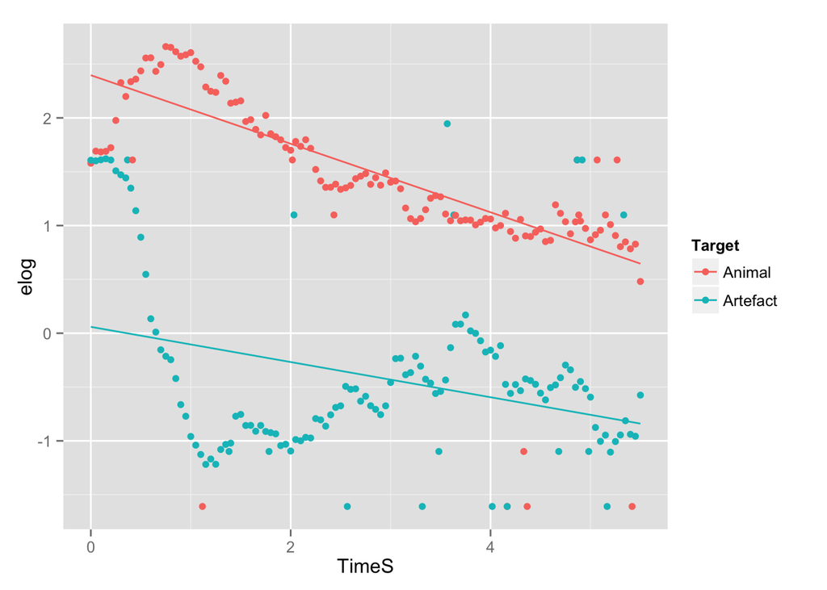

```r
ggplot(binned, aes(x=TimeS, y=elog, color=Target)) +
                     stat_summary(fun.y=mean, geom="point") +
                     stat_summary(aes(y=predict(model,binned,re.form=NA)), fun.y=mean, geom="line")
```

We already know that this model isn’t a great fit to our data. By assuming linear growth, it gives us weird estimates, one major one being that it thinks our two groups differ at timepoint 0 (which we know not to be true – the differences emerge over time).

# Natural polynomial growth curve analysis

Let’s do our first stab at examining non-linear growth by creating and entering natural polynomials into the model.

```r
binned <- binned %>%
          mutate(TimeS_2 = TimeS^2,
                 TimeS_3 = TimeS^3,
                 TimeS_4 = TimeS^4)

head(binned)
```

```
## Source: local data frame [6 x 14]
##
##   ParticipantName Target Bin PropAnimal y N TimeS    elog      wts
## 1        ANCAT139 Animal   1          1 3 3  0.05 1.94591 2.285714
## 2        ANCAT139 Animal   2          1 3 3  0.10 1.94591 2.285714
## 3        ANCAT139 Animal   3          1 3 3  0.15 1.94591 2.285714
## 4        ANCAT139 Animal   4          1 3 3  0.20 1.94591 2.285714
## 5        ANCAT139 Animal   5          1 3 3  0.25 1.94591 2.285714
## 6        ANCAT139 Animal   6          1 3 3  0.30 1.94591 2.285714
## Variables not shown: Arcsin (dbl), TargetC (dbl), TimeS_2 (dbl), TimeS_3
##   (dbl), TimeS_4 (dbl)
```

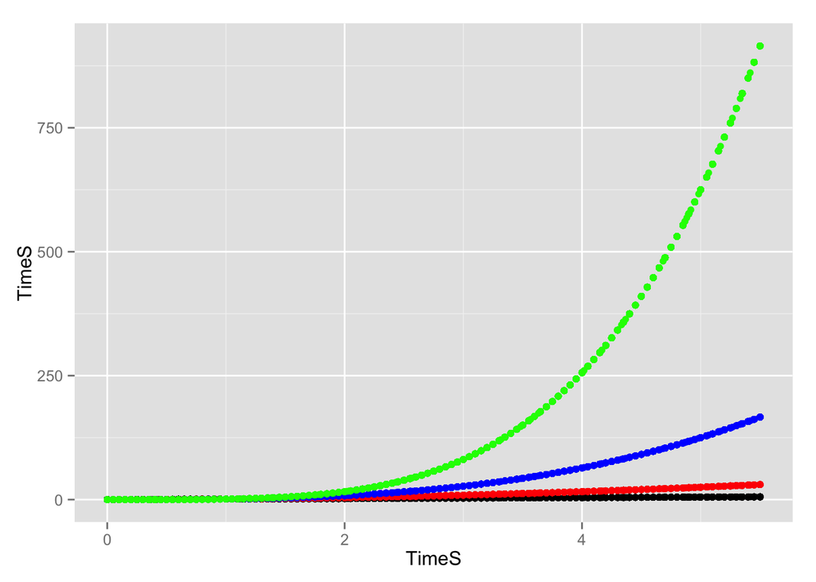

```r
ggplot(binned, aes(x=TimeS, y=TimeS)) +
               geom_point() +
               geom_point(aes(y=TimeS_2), color='red') +
               geom_point(aes(y=TimeS_3), color='blue') +
               geom_point(aes(y=TimeS_4), color='green')
```

Each natural polynomial accelerates at a different rate. These have an interesting property in that, when combined, they capture the correlates/estimated slopes of a variable at successive “bends” in the data. i.e., The 2nd (quadratic) polynomial will capture the first bend, the 3rd (cubic) polynomial will capture the second bend, and so on.

In this way, models that include these natural polynomials can model non-linear growth.

```r
model <- lmer(elog ~ Target*(TimeS + TimeS_2 + TimeS_3 + TimeS_4) + (1 + Target + TimeS + TimeS_2 + TimeS_3 + TimeS_4 | ParticipantName), data = binned)
summary(model)
```

```
## Linear mixed model fit by REML ['lmerMod']
## Formula: elog ~ Target * (TimeS + TimeS_2 + TimeS_3 + TimeS_4) + (1 +
##     Target + TimeS + TimeS_2 + TimeS_3 + TimeS_4 | ParticipantName)
##    Data: binned
##
## REML criterion at convergence: 22154
##
## Scaled residuals:
##      Min       1Q   Median       3Q      Max
## -3.02884 -0.74205  0.01878  0.67663  3.03478
##
## Random effects:
##  Groups          Name           Variance Std.Dev. Corr
##  ParticipantName (Intercept)    1.430660 1.19610
##                  TargetArtefact 1.096841 1.04730  -0.24
##                  TimeS          5.137607 2.26663  -0.30  0.08
##                  TimeS_2        3.174713 1.78177   0.03  0.02 -0.58
##                  TimeS_3        0.337531 0.58097   0.09 -0.02  0.41 -0.93
##                  TimeS_4        0.003629 0.06024  -0.14  0.01 -0.36  0.78
##  Residual                       1.564735 1.25089
##
##
##
##
##
##
##  -0.95
##
## Number of obs: 6526, groups:  ParticipantName, 30
##
## Fixed effects:
##                         Estimate Std. Error t value
## (Intercept)             1.642371   0.241679   6.796
## TargetArtefact          0.750439   0.240789   3.117
## TimeS                   2.123542   0.490856   4.326
## TimeS_2                -1.753652   0.380356  -4.611
## TimeS_3                 0.439360   0.119095   3.689
## TimeS_4                -0.035731   0.012042  -2.967
## TargetArtefact:TimeS   -7.295167   0.372474 -19.586
## TargetArtefact:TimeS_2  4.368586   0.277716  15.730
```

[output cut: 9 more lines]

```
## TimeS_4     -0.018 -0.091 -0.469  0.811 -0.957
## TrgtArtf:TS  0.259 -0.519 -0.381  0.355 -0.294  0.248
## TrgtAr:TS_2 -0.221  0.441  0.369 -0.367  0.318 -0.276 -0.967
## TrgtAr:TS_3  0.194 -0.389 -0.349  0.363 -0.323  0.286  0.913 -0.985
## TrgtAr:TS_4 -0.176  0.351  0.329 -0.352  0.321 -0.289 -0.861  0.957
##             TA:TS_3
## TargtArtfct
## TimeS
## TimeS_2
## TimeS_3
## TimeS_4
## TrgtArtf:TS
## TrgtAr:TS_2
## TrgtAr:TS_3
## TrgtAr:TS_4 -0.992
```

We have some convergence issues caused by overparameterization, so let’s scale back on these polynomials to something that seems more reasonable. A good rule of thumb is to count the number of “bends” in the data before breaking it down by condition.

How many bends do we see?

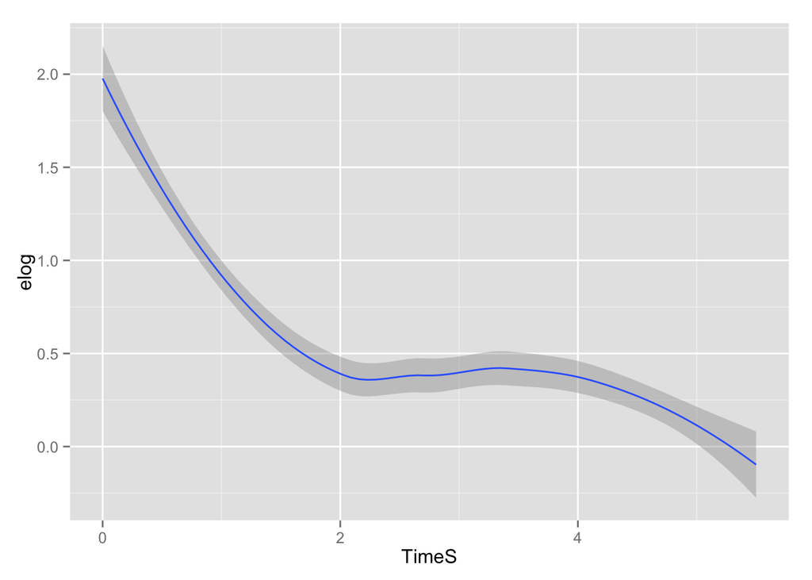

```r
ggplot(binned, aes(x=TimeS, y=elog)) +
               stat_smooth(method="loess")
```

There looks to be two bends in the data which, because of the N-1 relationship between polynomials and bends, means we should include 3 polynomial terms.

```r
model <- lmer(elog ~ Target*(TimeS + TimeS_2 + TimeS_3) + (1 + Target + TimeS + TimeS_2 + TimeS_3 | ParticipantName), data = binned)
summary(model)
```

```
## Linear mixed model fit by REML ['lmerMod']
## Formula:
## elog ~ Target * (TimeS + TimeS_2 + TimeS_3) + (1 + Target + TimeS +
##     TimeS_2 + TimeS_3 | ParticipantName)
##    Data: binned
##
## REML criterion at convergence: 22477.3
##
## Scaled residuals:
##     Min      1Q  Median      3Q     Max
## -2.8434 -0.7320  0.0330  0.6972  3.0251
##
## Random effects:
##  Groups          Name           Variance Std.Dev. Corr
##  ParticipantName (Intercept)    1.47588  1.2149
##                  TargetArtefact 1.17655  1.0847   -0.38
##                  TimeS          4.01804  2.0045   -0.55  0.14
##                  TimeS_2        0.96055  0.9801    0.32 -0.20 -0.94
##                  TimeS_3        0.01518  0.1232   -0.20  0.23  0.87 -0.98
##  Residual                       1.69721  1.3028
## Number of obs: 6526, groups:  ParticipantName, 30
##
## Fixed effects:
##                        Estimate Std. Error t value
## (Intercept)             2.08370    0.23867   8.731
## TargetArtefact         -0.07437    0.23390  -0.318
## TimeS                   0.44895    0.39189   1.146
## TimeS_2                -0.36833    0.18866  -1.952
## TimeS_3                 0.04626    0.02362   1.959
## TargetArtefact:TimeS   -4.16823    0.19737 -21.119
## TargetArtefact:TimeS_2  1.78000    0.08393  21.209
## TargetArtefact:TimeS_3 -0.20031    0.01006 -19.909
##
## Correlation of Fixed Effects:
##             (Intr) TrgtAr TimeS  TimS_2 TimS_3 TrA:TS TA:TS_2
## TargtArtfct -0.435
## TimeS       -0.595  0.226
## TimeS_2      0.369 -0.248 -0.944
## TimeS_3     -0.251  0.260  0.876 -0.985
## TrgtArtf:TS  0.225 -0.457 -0.254  0.217 -0.197
## TrgtAr:TS_2 -0.192  0.390  0.246 -0.225  0.213 -0.967
## TrgtAr:TS_3  0.170 -0.345 -0.233  0.222 -0.217  0.914 -0.986
```

There is still a convergence error, likely because the scales of our variables are too different, like before. We will ignore this for now, because our final GCA approach will fix this.

In the mean time, let’s see what this model did for us. Looking at the estimates above, it seems to have gotten rid of our timepoint 0 main effect of Target (yes!), and instead shows some strong interactions over time. This seems promising… but let’s visualize.

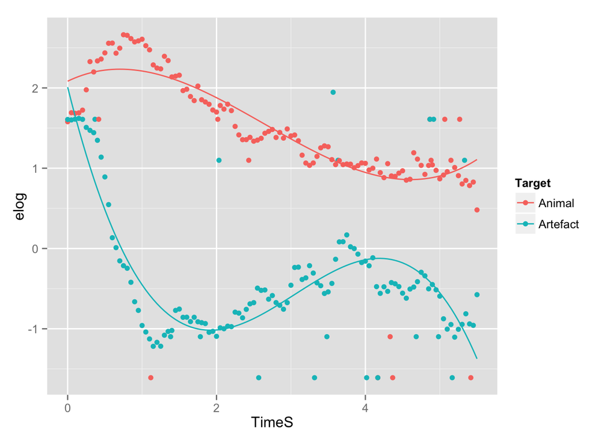

```r
ggplot(binned, aes(x=TimeS, y=elog, color=Target)) +
  stat_summary(fun.y=mean, geom="point") +
  stat_summary(aes(y=predict(model,binned,re.form=NA)), fun.y=mean, geom="line")
```

Awesome! Much better.

Let’s store this model because are going to use it for comparison later.

```r
natural_model <- model
```

# Orthogonal polynomial growth curve analysis

## Solving the multicollinearity of natural polynomials

We just did our first non-linear growth curve analysis, but it was sub-optimal for two reasons:

1. these polynomial terms we generated are highly correlated with one another, and multicollinearity in linear models is always bad
2. our model had trouble converging because of the different scales of our DV’s

Thankfully, we have something that will help: *orthogonal polynomials*.

Let’s first consider problem (1): our natural polynomial are highly correlated with each other. Here you can see this in a standard correlation matrix.

```r
cor(binned[, c('TimeS','TimeS_2','TimeS_3','TimeS_4')])
```

```
##             TimeS   TimeS_2   TimeS_3   TimeS_4
## TimeS   1.0000000 0.9673950 0.9148202 0.8637499
## TimeS_2 0.9673950 1.0000000 0.9858194 0.9578085
## TimeS_3 0.9148202 0.9858194 1.0000000 0.9920735
## TimeS_4 0.8637499 0.9578085 0.9920735 1.0000000
```

This is not a good thing when we are trying to attribute variance to each factor independently. This isn’t unique to time-based models – any linear model suffers from multicollinearity.

So, what we can do is actually create replacement timecodes for linear, quadratic, cubic, etc. change over time that we *know* by design will be uncorrelated.

`poly()` will generate higher-order polynomials for us, with a vector length equivalent to the length of our original time vector.

We’ll go up to 6th-order polynomials, but we’ll stick to the first 3 for most of our models.

```r
orthogonal_polynomials <- poly(sort(as.vector(unique(binned$TimeS))), 6)
head(orthogonal_polynomials)
```

```
##               1         2          3          4           5           6
## [1,] -0.1522008 0.1965879 -0.2280843 0.25890514 -0.28163291  0.29210413
## [2,] -0.1495809 0.1862187 -0.2038997 0.21335606 -0.20920324  0.18790281
## [3,] -0.1469609 0.1760350 -0.1808064 0.17149897 -0.14581956  0.10238653
## [4,] -0.1443409 0.1660370 -0.1587845 0.13317643 -0.09082299  0.03350625
## [5,] -0.1417209 0.1562246 -0.1378139 0.09823392 -0.04358204 -0.02064481
## [6,] -0.1391009 0.1465978 -0.1178747 0.06651981 -0.00349211 -0.06183707
```

Column 1 grows linearly. Column 2 grows quadratically. Column 3 grows cubicly… etc.

Visualize this, and verify that they are indeed uncorrelated.

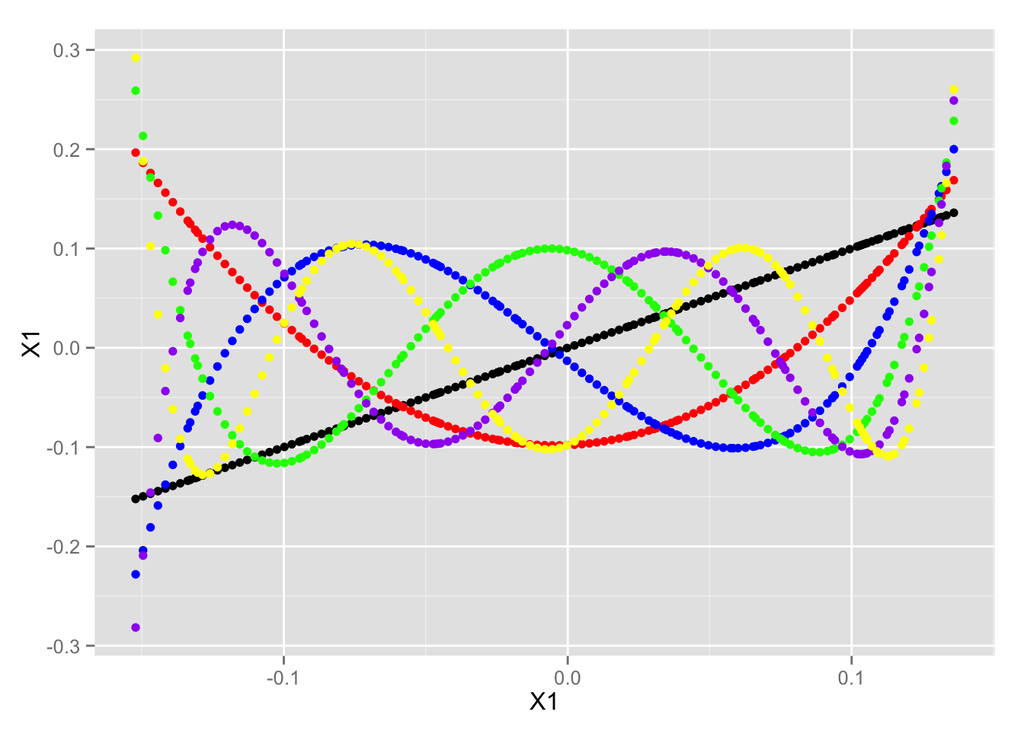

```r
ggplot(data.frame(orthogonal_polynomials), aes(x=X1, y=X1)) +
               geom_point() +
               geom_point(aes(y=X2), color='red') +
               geom_point(aes(y=X3), color='blue') +
               geom_point(aes(y=X4), color='green') +
               geom_point(aes(y=X5), color='purple') +
               geom_point(aes(y=X6), color='yellow')
```

```r
cor(orthogonal_polynomials[, c(1:6)])
```

```
##               1             2             3             4             5
## 1  1.000000e+00 -3.746257e-17 -6.884345e-17  6.189609e-17  5.817083e-17
## 2 -3.746257e-17  1.000000e+00 -5.529431e-18 -1.469433e-17 -1.280307e-16
## 3 -6.884345e-17 -5.529431e-18  1.000000e+00  2.886349e-16  3.596163e-17
## 4  6.189609e-17 -1.469433e-17  2.886349e-16  1.000000e+00 -1.673568e-16
## 5  5.817083e-17 -1.280307e-16  3.596163e-17 -1.673568e-16  1.000000e+00
## 6  2.201879e-16 -1.657135e-17 -2.105385e-17 -8.550967e-17 -7.173353e-17
##               6
## 1  2.201879e-16
## 2 -1.657135e-17
## 3 -2.105385e-17
## 4 -8.550967e-17
## 5 -7.173353e-17
## 6  1.000000e+00
```

```r
round(cor(orthogonal_polynomials[, c(1:6)]),5)
```

```
##   1 2 3 4 5 6
## 1 1 0 0 0 0 0
## 2 0 1 0 0 0 0
## 3 0 0 1 0 0 0
## 4 0 0 0 1 0 0
## 5 0 0 0 0 1 0
## 6 0 0 0 0 0 1
```

Perfect!

I like to merge them into the original dataframe using this technique, which allows for missing data from any given participant.

```r
time_codes <- data.frame(
                        sort(as.vector(unique(binned$TimeS))),
                        orthogonal_polynomials[, c(1:6)]
                      )
colnames(time_codes) <- c('TimeS','ot1','ot2','ot3','ot4','ot5','ot6')

binned <- merge(binned, time_codes, by='TimeS')
```

## Orthogonal modeling

Now let’s model our data exactly like we did before but using these orthogonal polynomials:

```r
model <- lmer(elog ~ TargetC*(ot1 + ot2 + ot3) + (1 + TargetC + ot1 + ot2 + ot3 | ParticipantName), data = binned)
summary(model)
```

```
## Linear mixed model fit by REML ['lmerMod']
## Formula: elog ~ TargetC * (ot1 + ot2 + ot3) + (1 + TargetC + ot1 + ot2 +
##     ot3 | ParticipantName)
##    Data: binned
##
## REML criterion at convergence: 22435.2
##
## Scaled residuals:
##      Min       1Q   Median       3Q      Max
## -2.83455 -0.73074  0.03328  0.69541  3.02566
##
## Random effects:
##  Groups          Name        Variance Std.Dev. Corr
##  ParticipantName (Intercept)  0.2764  0.5257
##                  TargetC      1.1894  1.0906   -0.12
##                  ot1         25.4028  5.0401    0.40 -0.01
##                  ot2         21.8758  4.6772    0.09 -0.19 -0.07
##                  ot3         20.1808  4.4923    0.02 -0.17 -0.59  0.12
##  Residual                     1.6970  1.3027
## Number of obs: 6526, groups:  ParticipantName, 30
##
## Fixed effects:
##             Estimate Std. Error t value
## (Intercept)  0.53405    0.09738   5.484
## TargetC      1.89048    0.20180   9.368
## ot1         -4.36032    0.94073  -4.635
## ot2          1.94414    0.87515   2.221
## ot3         -2.04657    0.84179  -2.431
## TargetC:ot1 -3.10083    0.39068  -7.937
## TargetC:ot2 -2.90937    0.38230  -7.610
## TargetC:ot3  7.52262    0.37782  19.910
##
## Correlation of Fixed Effects:
##             (Intr) TargtC ot1    ot2    ot3    TrgC:1 TrgC:2
## TargetC     -0.114
## ot1          0.392 -0.007
## ot2          0.090 -0.183 -0.057
## ot3          0.022 -0.168 -0.557  0.117
## TargetC:ot1  0.002  0.021  0.001  0.001  0.000
## TargetC:ot2  0.000  0.009  0.001  0.002  0.003  0.114
## TargetC:ot3 -0.001  0.002  0.000  0.003  0.002  0.026  0.088
```

Great fit! No errors.

Interestingly, we are back to seeing a main effect of `TargetArtefact`, though… Why? The reason is simple: Our natural polynomials all started at Timepoint 0, meaning that main effects represented differences at the *start* of the time window. In contrast, orthogonal polynomials are, by default, centered at 0, meaning that main effects represent *average* differences (across time) between levels of a factor.

Let’s visualize our data and model fit:

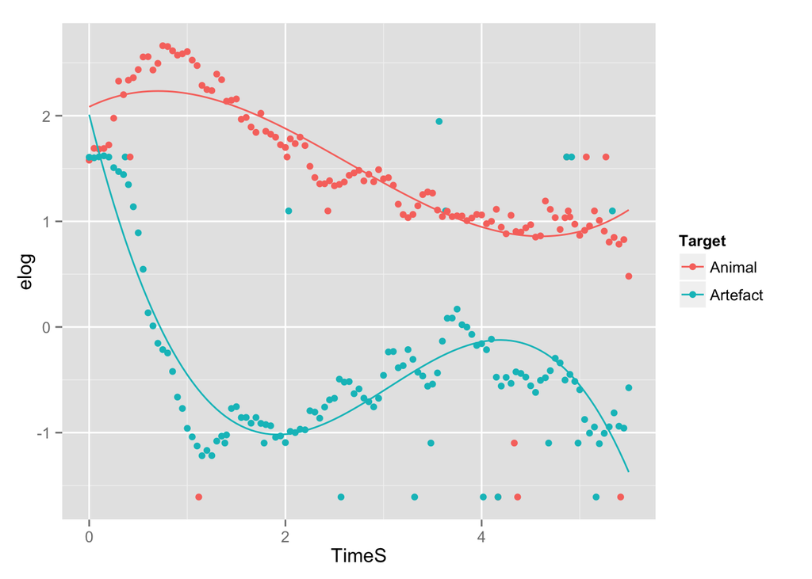

```r
ggplot(binned, aes(x=TimeS, y=elog, color=Target)) +
  stat_summary(fun.y=mean, geom="point") +
  stat_summary(aes(y=predict(model,binned,re.form=NA)), fun.y=mean, geom="line")
```

Compare this model to our natural polynomial model.

```r
summary(natural_model)
```

```
## Linear mixed model fit by REML ['lmerMod']
## Formula:
## elog ~ Target * (TimeS + TimeS_2 + TimeS_3) + (1 + Target + TimeS +
##     TimeS_2 + TimeS_3 | ParticipantName)
##    Data: binned
##
## REML criterion at convergence: 22477.3
##
## Scaled residuals:
##     Min      1Q  Median      3Q     Max
## -2.8434 -0.7320  0.0330  0.6972  3.0251
##
## Random effects:
##  Groups          Name           Variance Std.Dev. Corr
##  ParticipantName (Intercept)    1.47588  1.2149
##                  TargetArtefact 1.17655  1.0847   -0.38
##                  TimeS          4.01804  2.0045   -0.55  0.14
##                  TimeS_2        0.96055  0.9801    0.32 -0.20 -0.94
##                  TimeS_3        0.01518  0.1232   -0.20  0.23  0.87 -0.98
##  Residual                       1.69721  1.3028
## Number of obs: 6526, groups:  ParticipantName, 30
##
## Fixed effects:
##                        Estimate Std. Error t value
## (Intercept)             2.08370    0.23867   8.731
## TargetArtefact         -0.07437    0.23390  -0.318
## TimeS                   0.44895    0.39189   1.146
## TimeS_2                -0.36833    0.18866  -1.952
## TimeS_3                 0.04626    0.02362   1.959
## TargetArtefact:TimeS   -4.16823    0.19737 -21.119
## TargetArtefact:TimeS_2  1.78000    0.08393  21.209
## TargetArtefact:TimeS_3 -0.20031    0.01006 -19.909
##
## Correlation of Fixed Effects:
##             (Intr) TrgtAr TimeS  TimS_2 TimS_3 TrA:TS TA:TS_2
## TargtArtfct -0.435
## TimeS       -0.595  0.226
## TimeS_2      0.369 -0.248 -0.944
## TimeS_3     -0.251  0.260  0.876 -0.985
## TrgtArtf:TS  0.225 -0.457 -0.254  0.217 -0.197
## TrgtAr:TS_2 -0.192  0.390  0.246 -0.225  0.213 -0.967
## TrgtAr:TS_3  0.170 -0.345 -0.233  0.222 -0.217  0.914 -0.986
```

```r
summary(model)
```

```
## Linear mixed model fit by REML ['lmerMod']
## Formula: elog ~ TargetC * (ot1 + ot2 + ot3) + (1 + TargetC + ot1 + ot2 +
##     ot3 | ParticipantName)
##    Data: binned
##
## REML criterion at convergence: 22435.2
##
## Scaled residuals:
##      Min       1Q   Median       3Q      Max
## -2.83455 -0.73074  0.03328  0.69541  3.02566
##
## Random effects:
##  Groups          Name        Variance Std.Dev. Corr
##  ParticipantName (Intercept)  0.2764  0.5257
##                  TargetC      1.1894  1.0906   -0.12
##                  ot1         25.4028  5.0401    0.40 -0.01
##                  ot2         21.8758  4.6772    0.09 -0.19 -0.07
##                  ot3         20.1808  4.4923    0.02 -0.17 -0.59  0.12
##  Residual                     1.6970  1.3027
## Number of obs: 6526, groups:  ParticipantName, 30
##
## Fixed effects:
##             Estimate Std. Error t value
## (Intercept)  0.53405    0.09738   5.484
## TargetC      1.89048    0.20180   9.368
## ot1         -4.36032    0.94073  -4.635
## ot2          1.94414    0.87515   2.221
## ot3         -2.04657    0.84179  -2.431
## TargetC:ot1 -3.10083    0.39068  -7.937
## TargetC:ot2 -2.90937    0.38230  -7.610
## TargetC:ot3  7.52262    0.37782  19.910
##
## Correlation of Fixed Effects:
##             (Intr) TargtC ot1    ot2    ot3    TrgC:1 TrgC:2
## TargetC     -0.114
## ot1          0.392 -0.007
## ot2          0.090 -0.183 -0.057
## ot3          0.022 -0.168 -0.557  0.117
## TargetC:ot1  0.002  0.021  0.001  0.001  0.000
## TargetC:ot2  0.000  0.009  0.001  0.002  0.003  0.114
## TargetC:ot3 -0.001  0.002  0.000  0.003  0.002  0.026  0.088
```

We can use the same methods as before to get confidence intervals, test for Type III significance, etc.

```r
# confint(model)
  # this takes a long with a model this complex....

drop1(model, ~., test="Chisq")
```

```
## Single term deletions
##
## Model:
## elog ~ TargetC * (ot1 + ot2 + ot3) + (1 + TargetC + ot1 + ot2 +
##     ot3 | ParticipantName)
##             Df   AIC    LRT   Pr(Chi)
## <none>         22483
## TargetC      1 22523  41.80 1.012e-10 ***
## ot1          1 22497  16.61 4.592e-05 ***
## ot2          1 22486   4.72   0.02988 *
## ot3          1 22486   5.57   0.01826 *
## TargetC:ot1  1 22544  62.72 2.378e-15 ***
## TargetC:ot2  1 22538  57.69 3.075e-14 ***
## TargetC:ot3  1 22866 384.71 < 2.2e-16 ***
## ---
## Signif. codes:  0 '***' 0.001 '**' 0.01 '*' 0.05 '.' 0.1 ' ' 1
```

`drop1()` suggests that all of our parameters are reliable predictors.

Let’s try adding 4th and 5th orthogonal polynomials manually and seeing their effects on this model.

```r
model_quartic <- lmer(elog ~ TargetC*(ot1 + ot2 + ot3 + ot4) + (1 + TargetC + ot1 + ot2 + ot3 + ot4 | ParticipantName), data = binned)
summary(model_quartic)
```

```
## Linear mixed model fit by REML ['lmerMod']
## Formula: elog ~ TargetC * (ot1 + ot2 + ot3 + ot4) + (1 + TargetC + ot1 +
##     ot2 + ot3 + ot4 | ParticipantName)
##    Data: binned
##
## REML criterion at convergence: 21981
##
## Scaled residuals:
##      Min       1Q   Median       3Q      Max
## -3.07020 -0.73725  0.01891  0.67347  2.98970
##
## Random effects:
##  Groups          Name        Variance Std.Dev. Corr
##  ParticipantName (Intercept)  0.2797  0.5289
##                  TargetC      1.1826  1.0875   -0.12
##                  ot1         25.8122  5.0806    0.41  0.00
##                  ot2         21.7316  4.6617    0.09 -0.19 -0.07
##                  ot3         20.9333  4.5753   -0.01 -0.19 -0.60  0.09
##                  ot4         14.7505  3.8406   -0.35 -0.07 -0.26 -0.34
##  Residual                     1.5621  1.2498
##
##
##
##
##
##
##   0.16
##
## Number of obs: 6526, groups:  ParticipantName, 30
##
## Fixed effects:
##             Estimate Std. Error t value
## (Intercept)  0.53420    0.09784   5.460
## TargetC      1.90190    0.20103   9.461
## ot1         -4.36103    0.94637  -4.608
## ot2          1.95793    0.87075   2.249
## ot3         -2.03754    0.85514  -2.383
## ot4         -0.10087    0.72330  -0.139
## TargetC:ot1 -3.00666    0.37521  -8.013
## TargetC:ot2 -2.88869    0.36704  -7.870
## TargetC:ot3  7.23899    0.36436  19.868
## TargetC:ot4 -3.44293    0.35421  -9.720
##
## Correlation of Fixed Effects:
##             (Intr) TargtC ot1    ot2    ot3    ot4    TrgC:1 TrgC:2 TrgC:3
## TargetC     -0.114
## ot1          0.397 -0.001
## ot2          0.086 -0.185 -0.062
## ot3         -0.013 -0.181 -0.570  0.092
## ot4         -0.335 -0.070 -0.250 -0.320  0.153
## TargetC:ot1  0.002  0.020  0.002  0.001  0.000  0.001
## TargetC:ot2  0.000  0.009  0.001  0.002  0.003  0.002  0.115
## TargetC:ot3 -0.001  0.002  0.000  0.003  0.003  0.003  0.026  0.090
## TargetC:ot4  0.000 -0.003  0.001  0.001  0.002  0.001 -0.005  0.011  0.093
```

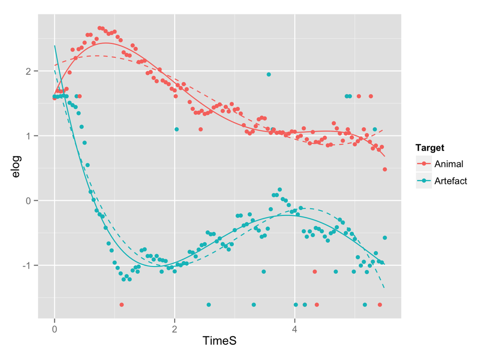

```r
ggplot(binned, aes(x=TimeS, y=elog, color=Target)) +
  stat_summary(fun.y=mean, geom="point") +
  stat_summary(aes(y=predict(model,binned,re.form=NA)), fun.y=mean, geom="line", linetype='dashed') + # 3rd-order model
  stat_summary(aes(y=predict(model_quartic,binned,re.form=NA)), fun.y=mean, geom="line") # 4th-order model
```

```r
anova(model, model_quartic)
```

```
## refitting model(s) with ML (instead of REML)
```

```
## Data: binned
## Models:
## model: elog ~ TargetC * (ot1 + ot2 + ot3) + (1 + TargetC + ot1 + ot2 +
## model:     ot3 | ParticipantName)
## model_quartic: elog ~ TargetC * (ot1 + ot2 + ot3 + ot4) + (1 + TargetC + ot1 +
## model_quartic:     ot2 + ot3 + ot4 | ParticipantName)
##               Df   AIC   BIC logLik deviance  Chisq Chi Df Pr(>Chisq)
## model         24 22483 22646 -11217    22435
## model_quartic 32 22045 22262 -10990    21981 453.79      8  < 2.2e-16 ***
## ---
## Signif. codes:  0 '***' 0.001 '**' 0.01 '*' 0.05 '.' 0.1 ' ' 1
```

Despite the very underwhelming difference in model fits, model comparison says that `ot4` is a significant predictor.

One possibility is that this significant difference is because we not only added `ot4` as a fixed effect, we also added it to the random structure. When examining the influence of a fixed effect, it’s best to keep your random effect structure constant. The fact that we changed our random structure is why the `anova()` says that our models differ by 8 degrees of freedom when we only wanted to see the influence of the main effect of `ot4` and its interaction with `TargetC` (i.e., two parameters or 2 df difference).

```r
model_cubic <- lmer(elog ~ TargetC*(ot1 + ot2 + ot3) + (1 + TargetC + ot1 + ot2 + ot3 + ot4 | ParticipantName), data = binned, REML=F)

model_quartic <- lmer(elog ~ TargetC*(ot1 + ot2 + ot3 + ot4) + (1 + TargetC + ot1 + ot2 + ot3 + ot4 | ParticipantName), data = binned, REML=F)

anova(model_cubic, model_quartic)
```

```
## Data: binned
## Models:
## model_cubic: elog ~ TargetC * (ot1 + ot2 + ot3) + (1 + TargetC + ot1 + ot2 +
## model_cubic:     ot3 + ot4 | ParticipantName)
## model_quartic: elog ~ TargetC * (ot1 + ot2 + ot3 + ot4) + (1 + TargetC + ot1 +
## model_quartic:     ot2 + ot3 + ot4 | ParticipantName)
##               Df   AIC   BIC logLik deviance  Chisq Chi Df Pr(>Chisq)
## model_cubic   30 22135 22338 -11037    22075
## model_quartic 32 22045 22262 -10990    21981 93.869      2  < 2.2e-16 ***
## ---
## Signif. codes:  0 '***' 0.001 '**' 0.01 '*' 0.05 '.' 0.1 ' ' 1
```

Despite the underwhelming difference in visualized model fits, it still says it’s a significantly better fit.

What about a 5th polynomial?

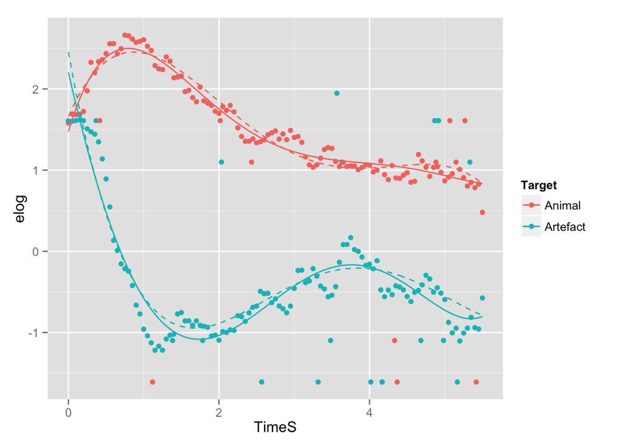

```r
model_quartic <- lmer(elog ~ TargetC*(ot1 + ot2 + ot3 + ot4) + (1 + TargetC + ot1 + ot2 + ot3 + ot4 + ot5 | ParticipantName), data = binned, REML=F)

model_quintic <- lmer(elog ~ TargetC*(ot1 + ot2 + ot3 + ot4 + ot5) + (1 + TargetC + ot1 + ot2 + ot3 + ot4 + ot5  | ParticipantName), data = binned, REML=F)

ggplot(binned, aes(x=TimeS, y=elog, color=Target)) +
  stat_summary(fun.y=mean, geom="point") +
  stat_summary(aes(y=predict(model_quartic,binned,re.form=NA)), fun.y=mean, geom="line", linetype='dashed') + # 4th-order model
  stat_summary(aes(y=predict(model_quintic,binned,re.form=NA)), fun.y=mean, geom="line") # 5th-order model
```

```r
anova(model_quartic, model_quintic)
```

```
## Data: binned
## Models:
## model_quartic: elog ~ TargetC * (ot1 + ot2 + ot3 + ot4) + (1 + TargetC + ot1 +
## model_quartic:     ot2 + ot3 + ot4 + ot5 | ParticipantName)
## model_quintic: elog ~ TargetC * (ot1 + ot2 + ot3 + ot4 + ot5) + (1 + TargetC +
## model_quintic:     ot1 + ot2 + ot3 + ot4 + ot5 | ParticipantName)
##               Df   AIC   BIC logLik deviance  Chisq Chi Df Pr(>Chisq)
## model_quartic 39 21847 22111 -10884    21769
## model_quintic 41 21849 22127 -10883    21767 1.7237      2     0.4224
```

Adding a 5th polynomial did not improve our fit.

Here’s a final reminder of how bad our linear model was:

```r
model_linear <- lmer(elog ~ TargetC*(ot1) + (1 + TargetC + ot1 | ParticipantName), data = binned)
summary(model_linear)
```

```
## Linear mixed model fit by REML ['lmerMod']
## Formula: elog ~ TargetC * (ot1) + (1 + TargetC + ot1 | ParticipantName)
##    Data: binned
##
## REML criterion at convergence: 23908
##
## Scaled residuals:
##      Min       1Q   Median       3Q      Max
## -2.92264 -0.79136  0.08027  0.73641  2.52996
##
## Random effects:
##  Groups          Name        Variance Std.Dev. Corr
##  ParticipantName (Intercept)  0.2753  0.5247
##                  TargetC      1.1661  1.0799   -0.12
##                  ot1         25.0545  5.0054    0.39  0.00
##  Residual                     2.1865  1.4787
## Number of obs: 6526, groups:  ParticipantName, 30
##
## Fixed effects:
##             Estimate Std. Error t value
## (Intercept)  0.52266    0.09757   5.357
## TargetC      1.88789    0.20061   9.411
## ot1         -4.58695    0.93999  -4.880
## TargetC:ot1 -2.95447    0.43935  -6.725
##
## Correlation of Fixed Effects:
##             (Intr) TargtC ot1
## TargetC     -0.114
## ot1          0.379 -0.002
## TargetC:ot1  0.002  0.022  0.001
```

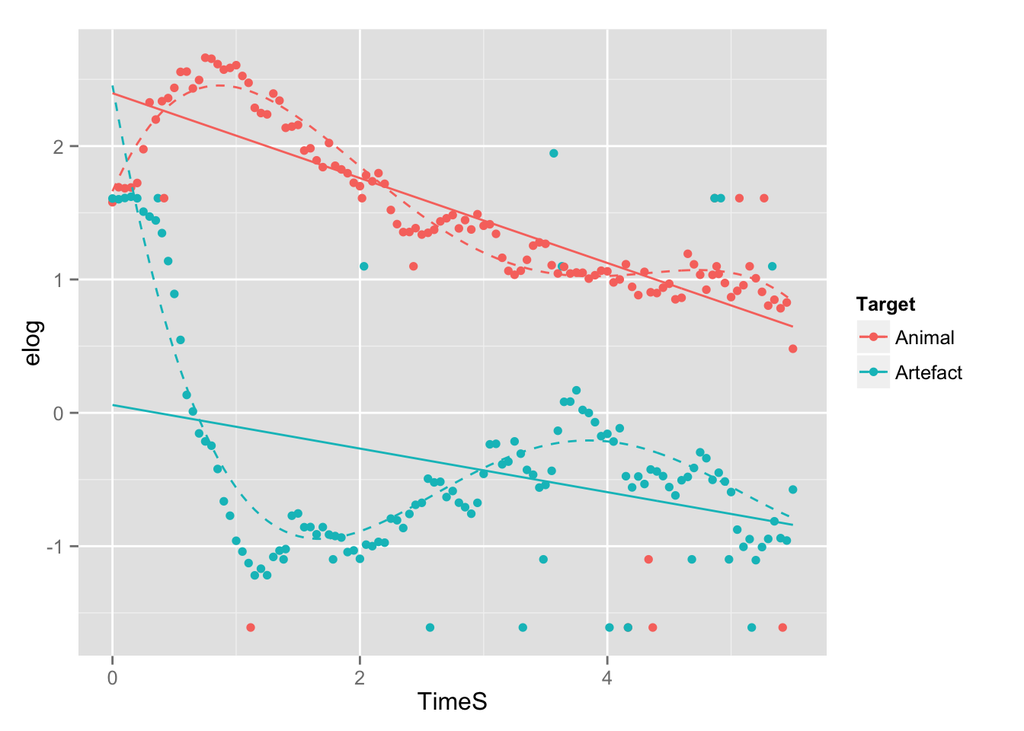

```r
ggplot(binned, aes(x=TimeS, y=elog, color=Target)) +
  stat_summary(fun.y=mean, geom="point") +
  stat_summary(aes(y=predict(model_quartic,binned,re.form=NA)), fun.y=mean, geom="line", linetype='dashed') + # 3rd-order model
  stat_summary(aes(y=predict(model_linear,binned,re.form=NA)), fun.y=mean, geom="line") # 2nd-order model
```

## Growth curve analyses with 3+ levels of a factor

I like to design experiments with only 2 levels per factor for simplicity but sometimes we have 3 levels in a factor and, now, main effects do not equal simple effects.

To demonstrate, let’s add a third “Neutral” Target level that will follow a similar trajectory to the “Animal” level but shifted down towards 50% chance.

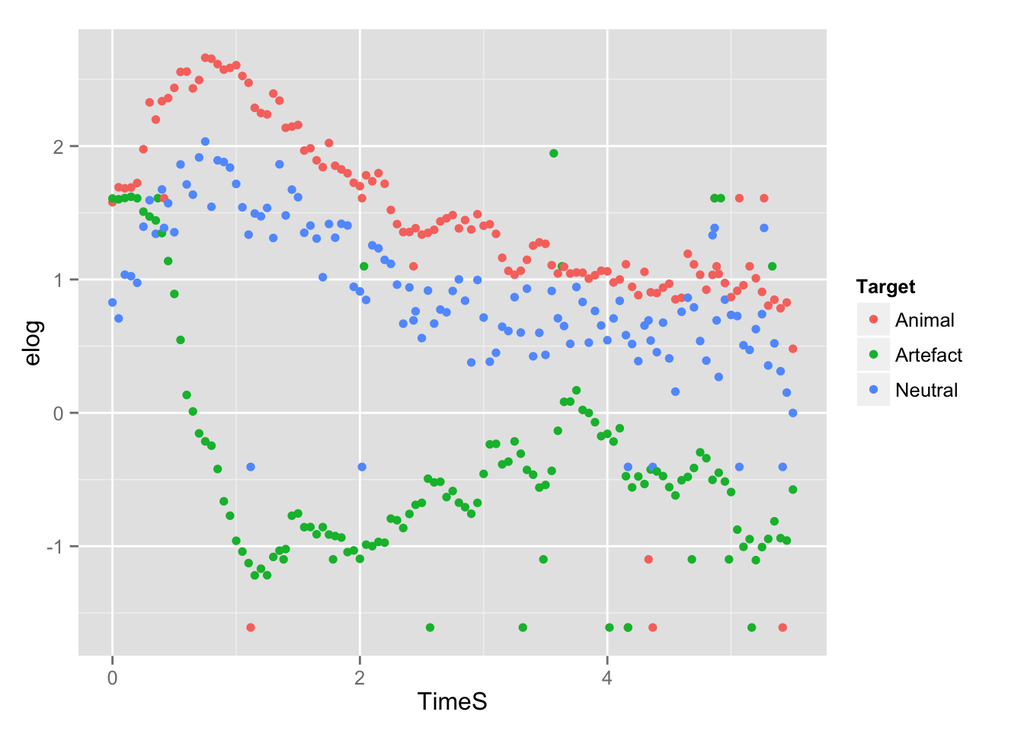

```r
new_condition <- binned[which(binned$Target == 'Animal'), ]
new_condition$Target <- 'Neutral'
#new_condition$y <- new_condition$y - round(new_condition$N / 3)
new_condition$y <- new_condition$y + round(rnorm(length(new_condition$y),-.5,2))
new_condition$y <- ifelse(new_condition$y > new_condition$N,new_condition$N,new_condition$y)
new_condition[which(new_condition$y < 1), 'y'] <- 1
new_condition$PropAnimal <- new_condition$y / new_condition$N
new_condition$elog <- log( (new_condition$y) / (new_condition$N - new_condition$y + .5) )
new_condition$wts <- 1/(new_condition$y + .5) + 1/(new_condition$N - new_condition$y + .5)
new_condition$Arcsin <- asin(sqrt(new_condition$PropAnimal))

binned_3levels <- rbind(binned,new_condition)
binned_3levels$Target <- factor(binned_3levels$Target)

ggplot(binned_3levels, aes(x=TimeS, y=elog, color=Target)) +
  stat_summary(fun.y=mean, geom="point")
```

Fit a model with Target treatment-coded.

```r
model <- lmer(elog ~ Target*(ot1 + ot2 + ot3) + (1 + Target + ot1 + ot2 + ot3 | ParticipantName), data = binned_3levels)
summary(model)
```

```
## Linear mixed model fit by REML ['lmerMod']
## Formula: elog ~ Target * (ot1 + ot2 + ot3) + (1 + Target + ot1 + ot2 +
##     ot3 | ParticipantName)
##    Data: binned_3levels
##
## REML criterion at convergence: 33287.2
##
## Scaled residuals:
##     Min      1Q  Median      3Q     Max
## -3.6196 -0.7165 -0.0016  0.7275  3.1674
##
## Random effects:
##  Groups          Name           Variance Std.Dev. Corr
##  ParticipantName (Intercept)     0.51151 0.7152
##                  TargetArtefact  1.19164 1.0916   -0.68
##                  TargetNeutral   0.03302 0.1817   -0.93  0.54
##                  ot1            19.05642 4.3654    0.38 -0.02 -0.54
##                  ot2            21.77520 4.6664   -0.09  0.24 -0.17  0.02
##                  ot3            17.99780 4.2424   -0.13  0.19  0.35 -0.57
##  Residual                        1.67853 1.2956
##
##
##
##
##
##
##   0.05
##
## Number of obs: 9770, groups:  ParticipantName, 30
##
## Fixed effects:
##                    Estimate Std. Error t value
## (Intercept)         1.48347    0.13262  11.186
## TargetArtefact     -1.88983    0.20194  -9.358
## TargetNeutral      -0.55324    0.04640 -11.923
## ot1                -5.93587    0.84346  -7.038
## ot2                 0.46424    0.89385   0.519
## ot3                 1.73069    0.81955   2.112
## TargetArtefact:ot1  3.11478    0.38802   8.027
## TargetNeutral:ot1   1.76129    0.38716   4.549
```

[output cut: 15 more lines]

```
## TrgtNtrl:t2 -0.006  0.004  0.037 -0.026 -0.213 -0.020  0.056  0.111  0.500
## TrgtArtfc:3 -0.001  0.002  0.005 -0.006 -0.021 -0.233  0.026  0.012  0.087
## TrgtNtrl:t3 -0.002  0.001  0.011 -0.006 -0.019 -0.229  0.012  0.025  0.044
##             TrgN:2 TrgA:3
## TargtArtfct
## TargetNetrl
## ot1
## ot2
## ot3
## TrgtArtfc:1
## TrgtNtrl:t1
## TrgtArtfc:2
## TrgtNtrl:t2
## TrgtArtfc:3  0.044
## TrgtNtrl:t3  0.088  0.501
```

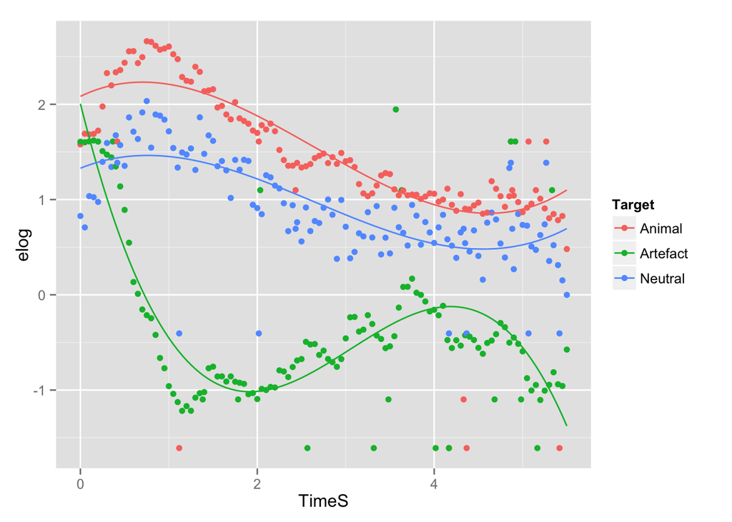

```r
ggplot(binned_3levels, aes(x=TimeS, y=elog, color=Target)) +
  stat_summary(fun.y=mean, geom="point") +
  stat_summary(aes(y=predict(model,binned_3levels,re.form=NA)), fun.y=mean, geom="line")
```

In order to know how to interpret these simple effects, we need to remember which is our reference level.

Get main effects via model comparison…

```r
model_null <- lmer(elog ~ Target*(ot1 + ot2) + ot3 + (1 + Target + ot1 + ot2 + ot3 | ParticipantName), data = binned_3levels)
summary(model_null)
```

```
## Linear mixed model fit by REML ['lmerMod']
## Formula: elog ~ Target * (ot1 + ot2) + ot3 + (1 + Target + ot1 + ot2 +
##     ot3 | ParticipantName)
##    Data: binned_3levels
##
## REML criterion at convergence: 33787.3
##
## Scaled residuals:
##     Min      1Q  Median      3Q     Max
## -3.6470 -0.7335  0.0212  0.7278  3.3502
##
## Random effects:
##  Groups          Name           Variance Std.Dev. Corr
##  ParticipantName (Intercept)     0.50708 0.7121
##                  TargetArtefact  1.18604 1.0891   -0.68
##                  TargetNeutral   0.02826 0.1681   -0.99  0.57
##                  ot1            19.63499 4.4311    0.36  0.00 -0.41
##                  ot2            21.63718 4.6516   -0.13  0.27  0.09  0.02
##                  ot3            18.27615 4.2751   -0.12  0.18  0.10 -0.59
##  Residual                        1.76795 1.3296
##
##
##
##
##
##
##   0.05
##
## Number of obs: 9770, groups:  ParticipantName, 30
##
## Fixed effects:
##                    Estimate Std. Error t value
## (Intercept)         1.48072    0.13217  11.203
## TargetArtefact     -1.87922    0.20162  -9.321
## TargetNeutral      -0.55160    0.04528 -12.183
## ot1                -6.01756    0.85715  -7.020
## ot2                 0.17904    0.89320   0.200
## ot3                -0.96946    0.79652  -1.217
## TargetArtefact:ot1  3.31958    0.39807   8.339
## TargetNeutral:ot1   1.77630    0.39721   4.472
## TargetArtefact:ot2  3.56848    0.38837   9.188
## TargetNeutral:ot2  -0.06304    0.38835  -0.162
##
## Correlation of Fixed Effects:
##             (Intr) TrgtAr TrgtNt ot1    ot2    ot3    TrgA:1 TrgN:1 TrgA:2
## TargtArtfct -0.679
## TargetNetrl -0.753  0.440
## ot1          0.345 -0.010 -0.281
## ot2         -0.114  0.252  0.049  0.032
## ot3         -0.114  0.173  0.066 -0.541  0.048
## TrgtArtfc:1 -0.017  0.021  0.045 -0.235 -0.025  0.000
## TrgtNtrl:t1 -0.015  0.010  0.089 -0.232 -0.024  0.000  0.499
## TrgtArtfc:2 -0.007  0.009  0.019 -0.027 -0.220 -0.002  0.111  0.055
## TrgtNtrl:t2 -0.007  0.004  0.038 -0.025 -0.218  0.000  0.055  0.109  0.500
```

```r
anova(model,model_null)
```

```
## refitting model(s) with ML (instead of REML)
```

```
## Data: binned_3levels
## Models:
## model_null: elog ~ Target * (ot1 + ot2) + ot3 + (1 + Target + ot1 + ot2 +
## model_null:     ot3 | ParticipantName)
## model: elog ~ Target * (ot1 + ot2 + ot3) + (1 + Target + ot1 + ot2 +
## model:     ot3 | ParticipantName)
##            Df   AIC   BIC logLik deviance  Chisq Chi Df Pr(>Chisq)
## model_null 32 33840 34070 -16888    33776
## model      34 33348 33592 -16640    33280 496.69      2  < 2.2e-16 ***
## ---
## Signif. codes:  0 '***' 0.001 '**' 0.01 '*' 0.05 '.' 0.1 ' ' 1
```

Get simple effects by re-ordering factor levels.

```r
levels(binned_3levels$Target)
```

```
## [1] "Animal"   "Artefact" "Neutral"
```

```r
binned_3levels$Target <- factor(binned_3levels$Target,c('Neutral','Animal','Artefact'))
levels(binned_3levels$Target)
```

```
## [1] "Neutral"  "Animal"   "Artefact"
```

```r
model <- lmer(elog ~ Target*(ot1 + ot2 + ot3) + (1 + Target + ot1 + ot2 + ot3 | ParticipantName), data = binned_3levels)
summary(model)
```

```
## Linear mixed model fit by REML ['lmerMod']
## Formula: elog ~ Target * (ot1 + ot2 + ot3) + (1 + Target + ot1 + ot2 +
##     ot3 | ParticipantName)
##    Data: binned_3levels
##
## REML criterion at convergence: 33292.4
##
## Scaled residuals:
##     Min      1Q  Median      3Q     Max
## -3.6069 -0.7125 -0.0104  0.7277  3.1666
##
## Random effects:
##  Groups          Name           Variance Std.Dev. Corr
##  ParticipantName (Intercept)     0.30236 0.5499
##                  TargetAnimal    0.02719 0.1649    1.00
##                  TargetArtefact  0.98719 0.9936   -0.59 -0.59
##                  ot1            19.12296 4.3730    0.35  0.35  0.06
##                  ot2            21.61993 4.6497   -0.13 -0.13  0.27  0.02
##                  ot3            17.93585 4.2351   -0.10 -0.10  0.17 -0.57
##  Residual                        1.67951 1.2960
##
##
##
##
##
##
##   0.05
##
## Number of obs: 9770, groups:  ParticipantName, 30
##
## Fixed effects:
##                    Estimate Std. Error t value
## (Intercept)         0.93108    0.10302   9.038
## TargetAnimal        0.55179    0.04426  12.466
## TargetArtefact     -1.33743    0.18429  -7.257
## ot1                -4.17221    0.84469  -4.939
## ot2                 0.36452    0.89093   0.409
## ot3                 1.34804    0.81821   1.648
## TargetAnimal:ot1   -1.76470    0.38726  -4.557
## TargetArtefact:ot1  1.35106    0.38791   3.483
```

[output cut: 15 more lines]

```
## TrgtArtfc:2 -0.009  0.019  0.010 -0.027 -0.216 -0.022  0.055    0.113
## TrgtAnml:t3 -0.003  0.012  0.002 -0.006 -0.019 -0.229  0.025    0.013
## TrgtArtfc:3 -0.002  0.006  0.003 -0.006 -0.021 -0.233  0.012    0.026
##             TrgtAn:2 TrgtAr:2 TrgtAn:3
## TargetAniml
## TargtArtfct
## ot1
## ot2
## ot3
## TrgtAnml:t1
## TrgtArtfc:1
## TrgtAnml:t2
## TrgtArtfc:2  0.500
## TrgtAnml:t3  0.088    0.044
## TrgtArtfc:3  0.044    0.087    0.500
```

Clean up our workspace.

```r
ls()
```

```
##  [1] "binned"                 "binned_3levels"
##  [3] "binned2"                "curWarnings"
##  [5] "data"                   "model"
##  [7] "model_cubic"            "model_linear"
##  [9] "model_null"             "model_quartic"
## [11] "model_quintic"          "natural_model"
## [13] "new_condition"          "orthogonal_polynomials"
## [15] "time_codes"
```

```r
rm(list=ls())
```